# CreditCard Fraud Detection

Kevin McCullough

May 15, 2017

Built with 3.3.3

### In this program, I am analyzing a credit card dataset to predict fraud. The data is highly imbalanced, so I will use Area Under Curve of an ROC model, and F1 scores as my criteria for selection. AUC is maximized with the best balance of the true positive and false positive rate, and F1 is a combination of precision and recall, that is maximized by finding a good balance of each, and not sacrificing one metric for the other. Accuracy will be monitored, but is not a great metric for highly unbalanced data.

# Set Working Directory

```r
setwd('C:/Users/m339673/Desktop/CreditCard')
```

# Load Libraries

```r
library(randomForest)
library(e1071)
library(rpart)
library(rpart.plot)
library(DMwR)
library(ROCR)
library(class)
library(ggplot2)
```

# Inputting Data and viewing summary of variables

```r
card <- read.csv("creditcard.csv")
summary(card)
```

```
##       Time              V1                  V2
##  Min.   :     0   Min.   :-56.40751   Min.   :-72.71573
##  1st Qu.: 54202   1st Qu.: -0.92037   1st Qu.: -0.59855
##  Median : 84692   Median :  0.01811   Median :  0.06549
##  Mean   : 94814   Mean   :  0.00000   Mean   :  0.00000
##  3rd Qu.:139321   3rd Qu.:  1.31564   3rd Qu.:  0.80372
##  Max.   :172792   Max.   :  2.45493   Max.   : 22.05773
##        V3                 V4                 V5
##  Min.   :-48.3256   Min.   :-5.68317   Min.   :-113.74331
##  1st Qu.: -0.8904   1st Qu.:-0.84864   1st Qu.:  -0.69160
##  Median :  0.1799   Median :-0.01985   Median :  -0.05434
##  Mean   :  0.0000   Mean   : 0.00000   Mean   :   0.00000
##  3rd Qu.:  1.0272   3rd Qu.: 0.74334   3rd Qu.:   0.61193
##  Max.   :  9.3826   Max.   :16.87534   Max.   :  34.80167
##        V6                 V7                 V8
##  Min.   :-26.1605   Min.   :-43.5572   Min.   :-73.21672
##  1st Qu.: -0.7683   1st Qu.: -0.5541   1st Qu.: -0.20863
##  Median : -0.2742   Median :  0.0401   Median :  0.02236
##  Mean   :  0.0000   Mean   :  0.0000   Mean   :  0.00000
##  3rd Qu.:  0.3986   3rd Qu.:  0.5704   3rd Qu.:  0.32735
##  Max.   : 73.3016   Max.   :120.5895   Max.   : 20.00721
##        V9                 V10                 V11
##  Min.   :-13.43407   Min.   :-24.58826   Min.   :-4.79747
##  1st Qu.: -0.64310   1st Qu.: -0.53543   1st Qu.:-0.76249
##  Median : -0.05143   Median : -0.09292   Median :-0.03276
##  Mean   :  0.00000   Mean   :  0.00000   Mean   : 0.00000
##  3rd Qu.:  0.59714   3rd Qu.:  0.45392   3rd Qu.: 0.73959
##  Max.   : 15.59500   Max.   : 23.74514   Max.   :12.01891
##       V12                V13                V14
##  Min.   :-18.6837   Min.   :-5.79188   Min.   :-19.2143
##  1st Qu.: -0.4056   1st Qu.:-0.64854   1st Qu.: -0.4256
##  Median :  0.1400   Median :-0.01357   Median :  0.0506
##  Mean   :  0.0000   Mean   : 0.00000   Mean   :  0.0000
##  3rd Qu.:  0.6182   3rd Qu.: 0.66251   3rd Qu.:  0.4931
##  Max.   :  7.8484   Max.   : 7.12688   Max.   : 10.5268
##       V15                V16                 V17
##  Min.   :-4.49894   Min.   :-14.12985   Min.   :-25.16280
##  1st Qu.:-0.58288   1st Qu.: -0.46804   1st Qu.: -0.48375
##  Median : 0.04807   Median :  0.06641   Median : -0.06568
##  Mean   : 0.00000   Mean   :  0.00000   Mean   :  0.00000
```

[output cut: 22 more lines]

```
##  Max.   : 4.58455   Max.   :  7.51959   Max.   : 3.51735
##       V27                  V28                Amount
##  Min.   :-22.565679   Min.   :-15.43008   Min.   :    0.00
##  1st Qu.: -0.070840   1st Qu.: -0.05296   1st Qu.:    5.60
##  Median :  0.001342   Median :  0.01124   Median :   22.00
##  Mean   :  0.000000   Mean   :  0.00000   Mean   :   88.35
##  3rd Qu.:  0.091045   3rd Qu.:  0.07828   3rd Qu.:   77.17
##  Max.   : 31.612198   Max.   : 33.84781   Max.   :25691.16
##      Class
##  Min.   :0.000000
##  1st Qu.:0.000000
##  Median :0.000000
##  Mean   :0.001728
##  3rd Qu.:0.000000
##  Max.   :1.000000
```

```r
head(card,n=5)
```

```
##   Time         V1          V2        V3         V4          V5          V6
## 1    0 -1.3598071 -0.07278117 2.5363467  1.3781552 -0.33832077  0.46238778
## 2    0  1.1918571  0.26615071 0.1664801  0.4481541  0.06001765 -0.08236081
## 3    1 -1.3583541 -1.34016307 1.7732093  0.3797796 -0.50319813  1.80049938
## 4    1 -0.9662717 -0.18522601 1.7929933 -0.8632913 -0.01030888  1.24720317
## 5    2 -1.1582331  0.87773676 1.5487178  0.4030339 -0.40719338  0.09592146
##            V7          V8         V9         V10        V11         V12
## 1  0.23959855  0.09869790  0.3637870  0.09079417 -0.5515995 -0.61780086
## 2 -0.07880298  0.08510165 -0.2554251 -0.16697441  1.6127267  1.06523531
## 3  0.79146096  0.24767579 -1.5146543  0.20764287  0.6245015  0.06608369
## 4  0.23760894  0.37743587 -1.3870241 -0.05495192 -0.2264873  0.17822823
## 5  0.59294075 -0.27053268  0.8177393  0.75307443 -0.8228429  0.53819555
##          V13        V14        V15        V16        V17         V18
## 1 -0.9913898 -0.3111694  1.4681770 -0.4704005  0.2079712  0.02579058
## 2  0.4890950 -0.1437723  0.6355581  0.4639170 -0.1148047 -0.18336127
## 3  0.7172927 -0.1659459  2.3458649 -2.8900832  1.1099694 -0.12135931
## 4  0.5077569 -0.2879237 -0.6314181 -1.0596472 -0.6840928  1.96577500
## 5  1.3458516 -1.1196698  0.1751211 -0.4514492 -0.2370332 -0.03819479
##          V19         V20          V21          V22        V23         V24
## 1  0.4039930  0.25141210 -0.018306778  0.277837576 -0.1104739  0.06692808
## 2 -0.1457830 -0.06908314 -0.225775248 -0.638671953  0.1012880 -0.33984648
## 3 -2.2618571  0.52497973  0.247998153  0.771679402  0.9094123 -0.68928096
## 4 -1.2326220 -0.20803778 -0.108300452  0.005273597 -0.1903205 -1.17557533
## 5  0.8034869  0.40854236 -0.009430697  0.798278495 -0.1374581  0.14126698
##          V25        V26          V27         V28 Amount Class
## 1  0.1285394 -0.1891148  0.133558377 -0.02105305 149.62     0
## 2  0.1671704  0.1258945 -0.008983099  0.01472417   2.69     0
## 3 -0.3276418 -0.1390966 -0.055352794 -0.05975184 378.66     0
## 4  0.6473760 -0.2219288  0.062722849  0.06145763 123.50     0
## 5 -0.2060096  0.5022922  0.219422230  0.21515315  69.99     0
```

# Modify the variables

```r
card$Class<-factor(card$Class) #Class variable to factor
card$Amount_scaled<-scale(card$Amount) #Scale the amount
```

# Variables to use for modeling(Removing Time and Amount)

```r
vars.to.use<-colnames(card)[c(-1,-30)]
data<-as.data.frame(card[,vars.to.use])
numericVars<-colnames(data[c(-29,-31)])
outcome<-'Class'
pos<-'1'
```

# Split data into training and test datasets

```r
set.seed(1234)
data$gp<-runif(dim(data)[1])
test<-subset(data, data$gp<=.3) #test data
train<-subset(data, data$gp>.3) #initial training before split
```

# Check output Class distribution for baseline accuracy

```r
as.numeric(table(train$Class)[1]/dim(train)[1])
```

```
## [1] 0.998224
```

```r
as.numeric(table(test$Class)[1]/dim(test)[1])
```

```
## [1] 0.9983857
```

# Balance training data using SMOTE to balance classes

```r
newcard<-SMOTE(Class ~ .,train,perc.over=10000, perc.under=101)
table(newcard$Class)
```

```
##
##     0     1
## 35754 35754
```

# Split balanced training data into training and calibration datasets

```r
useforCal<-rbinom(n=dim(newcard)[[1]],size=1, prob=0.1)>0 #index rows to be used for calibration
Cal<-subset(newcard,useforCal) #calibration data
credtrain<-subset(newcard,!useforCal) #training data
dim(credtrain)[1]
```

```
## [1] 64288
```

```r
dim(Cal)[1]
```

```
## [1] 7220
```

# Check output Class distribution for new training and calibration sets

```r
as.numeric(table(credtrain$Class)[1]/dim(credtrain)[1])
```

```
## [1] 0.5012288
```

```r
as.numeric(table(Cal$Class)[1]/dim(Cal)[1])
```

```
## [1] 0.4890582
```

# Start modeling process with building single variable models as baseline

## Convenience function to calculate Area Under Curve AUC

```r
calcAUC <- function(predcol,outcol) {
  perf <- performance(prediction(predcol,outcol==pos),'auc')
  as.numeric(perf@y.values)
}
```

## Convenience Functions to give class probabilities for Class and Numeric Variables

```r
mkPredC <- function(outCol,varCol,fraudCol) {
  pPos <- sum(outCol==pos)/length(outCol)
  naTab <- table(as.factor(outCol[is.na(varCol)]))
  pPosWna <- (naTab/sum(naTab))[as.character(pos)]
  vTab <- table(as.factor(outCol),varCol)
  pPosWv <- (vTab[as.character(pos),]+1.0e-3*pPos)/(colSums(vTab)+1.0e-3)
  pred <- pPosWv[fraudCol]
  pred[is.na(fraudCol)] <- pPosWna
  pred[is.na(pred)] <- pPos
  pred
}

mkPredN<-function(outCol, varCol,fraudCol) {
  cuts<-unique(as.numeric(quantile(varCol,
    probs=seq(0,1,0.1),na.rm=T)))
  varC<-cut(varCol,cuts)
  fraudC<-cut(fraudCol,cuts)
  mkPredC(outCol,varC,fraudC)
}
```

# Calculate AUC for all variables and print if AUC>.85 on Training data

```r
for(v in numericVars) {
  pi <- paste('pred',v,sep='')
  credtrain[,pi] <- mkPredN(credtrain[,outcome],credtrain[,v],credtrain[,v])
  test[,pi] <- mkPredN(credtrain[,outcome],credtrain[,v],test[,v])
  Cal[,pi] <- mkPredN(credtrain[,outcome],credtrain[,v],Cal[,v])
  aucTrain <- calcAUC(credtrain[,pi],credtrain[,outcome])
  if(aucTrain>=0.85) {
    aucCal <- calcAUC(Cal[,pi],Cal[,outcome])
    print(sprintf("%s, trainAUC: %4.3f calibrationAUC: %4.3f",
                  pi,aucTrain,aucCal))
  }
}
```

```
## [1] "predV2, trainAUC: 0.865 calibrationAUC: 0.865"
## [1] "predV3, trainAUC: 0.911 calibrationAUC: 0.915"
## [1] "predV4, trainAUC: 0.936 calibrationAUC: 0.938"
## [1] "predV7, trainAUC: 0.867 calibrationAUC: 0.860"
## [1] "predV10, trainAUC: 0.922 calibrationAUC: 0.922"
## [1] "predV11, trainAUC: 0.914 calibrationAUC: 0.910"
## [1] "predV12, trainAUC: 0.935 calibrationAUC: 0.933"
## [1] "predV14, trainAUC: 0.952 calibrationAUC: 0.953"
## [1] "predV16, trainAUC: 0.879 calibrationAUC: 0.878"
## [1] "predV17, trainAUC: 0.921 calibrationAUC: 0.925"
```

# Attempt to build a decision tree

```r
#Variable selection by picking variables with deviance improvement on Calibration dataset

logLikelyhood <- function(outCol,predCol) {
  sum(ifelse(outCol==pos,log(predCol),log(1-predCol)))
}

selVars <- c()
minStep <- 5
baseRateCheck <- logLikelyhood(Cal[,outcome],
                               sum(Cal[,outcome]==pos)/length(Cal[,outcome]))

for(v in numericVars) {
  pi <- paste('pred',v,sep='')
  liCheck <- 2*((logLikelyhood(Cal[,outcome],Cal[,pi]) -
                   baseRateCheck))
  if(liCheck>=minStep) {
    print(sprintf("%s, calibrationScore: %g",
                  pi,liCheck))
    selVars <- c(selVars,pi)
  }
}
```

```
## [1] "predV1, calibrationScore: 2496.56"
## [1] "predV2, calibrationScore: 3694.28"
## [1] "predV3, calibrationScore: 4919.05"
## [1] "predV4, calibrationScore: 5517.29"
## [1] "predV5, calibrationScore: 2271.8"
## [1] "predV6, calibrationScore: 2283.86"
## [1] "predV8, calibrationScore: 1915.85"
## [1] "predV9, calibrationScore: 3479.95"
## [1] "predV10, calibrationScore: 5852.51"
## [1] "predV11, calibrationScore: 5243.87"
## [1] "predV12, calibrationScore: 5746.56"
## [1] "predV13, calibrationScore: 110.401"
## [1] "predV14, calibrationScore: 6661.3"
## [1] "predV17, calibrationScore: 5384.13"
## [1] "predV18, calibrationScore: 2641.2"
## [1] "predV19, calibrationScore: 1384.71"
## [1] "predV20, calibrationScore: 1356.05"
## [1] "predV21, calibrationScore: 2661.79"
## [1] "predV22, calibrationScore: 37.683"
## [1] "predV23, calibrationScore: 651.548"
## [1] "predV24, calibrationScore: 370.46"
## [1] "predV25, calibrationScore: 83.8542"
## [1] "predV26, calibrationScore: 153.829"
## [1] "predV27, calibrationScore: 2795.42"
## [1] "predV28, calibrationScore: 2040.05"
## [1] "predAmount_scaled, calibrationScore: 461.632"
```

```r
f <- paste(outcome,'==1 ~ ',paste(selVars,collapse=' + '),sep='') #Building the formula using the Variables that improved deviance
tmodel <- rpart(f,data=credtrain,
                control=rpart.control(cp=0.001,minsplit=1000,
                                      minbucket=1000,maxdepth=5)
)

#Save predictions as a variable in each dataset
credtrain$tpred<-predict(tmodel,newdata=credtrain)
Cal$tpred<-predict(tmodel,newdata=Cal)
test$tpred<-predict(tmodel,newdata=test)

calcAUC(credtrain$tpred,credtrain[,outcome])
```

```
## [1] 0.9762058
```

```r
calcAUC(Cal$tpred,Cal[,outcome])
```

```
## [1] 0.9772177
```

```r
calcAUC(test$tpred,test[,outcome])
```

```
## [1] 0.9806518
```

## AUC on Test Data: 0.9806518

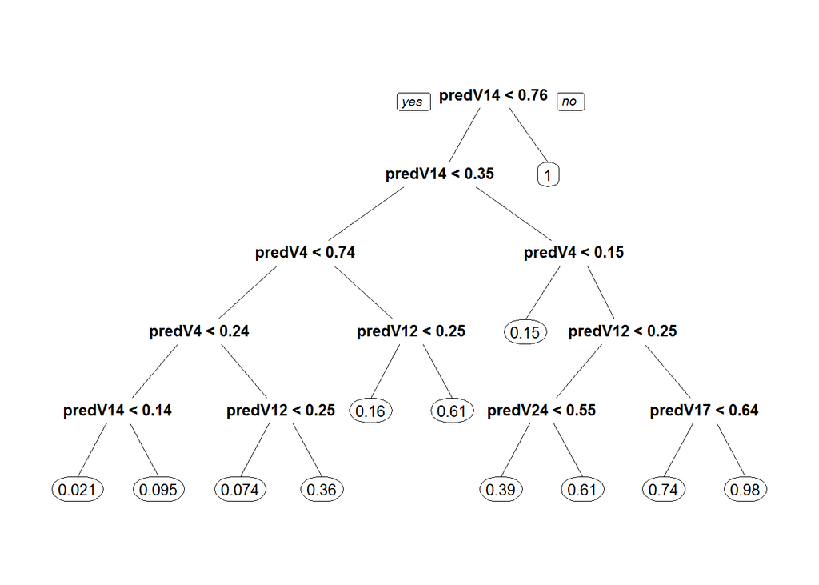

```r
prp(tmodel)
```